# Impact of Industrial Activity on Community Health

*Matthew Ueckermann*

## Problem

I am interested in exploring how industrial pollution impacts the health of surrounding communities. Specifically, by following a thread of my [midterm](https://matthewueckermann.github.io/CISC367Midterm/html/cleanNotebook.html) assignment where I investigated toxic chemical releases, I am curious how these releases correlate with markers of community health. Two main correlations which come to mind are those between carcinogen releases and cancer rates as well as the release of specific chemicals and asthma rates. I want to see if clear correlations exist between emissions and these health issues and if they do exist the magnitude of the effect.

## Background

Various industries release or cause the release of chemicals and particulates which have the potential to directly and severely impact the health and lives of those in the surrounding community. Releases of toxic chemicals are often mitigated to some extent to meet local air pollution licensing requirements and to prevent negative press attention. However, due to the nature of the equipment used as well as the effectiveness of mitigation technology, some releases will occur. While other industrial activities, like [mountain removal mining](https://en.wikipedia.org/wiki/Mountaintop_removal_mining#Health_impacts), cause the release of large amounts of particulates as well as toxic chemicals which cannot be easily controlled.

The fact that industries pollute chemicals which have been shown to be toxic in lab settings or which are believed to cause lung disorders, begs the question of whether these emissions have demonstrable effects on markers of community health. Do elevated quantities of exposure to these chemicals cause higher cancer rates? Or are chemicals emitted in small enough quantities that other factors dominate whether or not people develop certain disorders. This information equips communities with the knowledge about whether they should be concerned about surrounding industrial activity as well the extent to push for greater emission control or use of safer practices.

## Research Questions

- To what extent can the cities with higher than average rates of cancer be predicted by looking at carcinogen release from facilities in the same county?
- Do any routes of chemical release (air, water, landfill) cause a greater associated rate of cancer?
- To what extent can cities with higher than average rates of asthma be predicted by looking at rates of nitrogen oxide and particulate matter emissions?
- Do communities with a more active mining sector have a greater associated rate of asthma then those that do not?

## Justification

For the first question, carcinogens are by [definition](https://www.cancer.gov/about-cancer/causes-prevention/risk/substances/carcinogens) compounds which are believed to cause cancer. Exposure limits have historically been defined in terms of [occupational exposure limits](https://www.cdc.gov/niosh/npg/nengapdxa.html), as these are where people are generally exposed to large enough quantities of these compounds frequently enough for them to make a difference. However, it is less straightforward to define exposure quantities which could cause surrounding communities to develop cancer at higher rates. Some studies show that atmospheric carcinogens in the UK have been linked with higher child cancer rates [1]. Completing a similar study in the US could give residents important knowledge about the facilities that surround them.

The second question then builds on this to see if there is a noticeable difference based on emission route. As my midterm showed that the majority of emissions are emitted to the air, I was interested if the amount emitted to the water, impacts health in a more detrimental way.

For the third question, it is widely accepted that exposure to particulates as well as oxides can trigger asthma attacks and may also lead to the development of new-onset asthma in some people [2]. It would be interesting to characterize whether emissions from industrial facilities play a role in exacerbating this condition, or if the particulates and other compounds which trigger asthma can be primarily attributed to transportation - another major source of these compounds. This could equip residents with extra knowledge of what to attribute their asthma too and what types of facilities to avoid to prevent triggering it.

The fourth question builds off of the third, by investigating the impact of mining specifically on asthma. This is because some forms of mining, namely mountain strip top, have been associated with increased amount of respiratory disorders, including asthma [3]. This builds on the history of lung disorders associated with mining, notably [black lung](https://en.wikipedia.org/wiki/Coalworker%27s_pneumoconiosis) in coal miners. This could show that entire communities, not just workers, are impacted by exposure brought about by the mining industry.

[1] Knox, E.G. (2005). Childhood cancers and atmospheric carcinogens. *Journal Epidemiol Community Healthy*, 59, 101-105. http://dx.doi.org/10.1136/jech.2004.021675

[2] Guarnieri, M. and Balmes, J.R. (2014). Outdoor air pollution and asthma. *Lancet*, 383(9928), 1561-1592. https://doi.org/10.1016/S0140-6736(14)60617-6

[3] Hendryx, M. (2013). Personal and family health in rural areas of Kentucky with and without mountaintop coal mining. *The Journal of Rural Health*, 29, s79-288. https://doi-org.udel.idm.oclc.org/10.1111/jrh.12016

## Datasets

To characterize chemical releases I plan to return to the dataset I used for the midterm, the TRI which has data from 1987-2019 accessible in csv files [here](https://www.epa.gov/toxics-release-inventory-tri-program/tri-basic-data-files-calendar-years-1987-2019?). In this case; however, I will most likely only focus on the 2018 data, as for health indicators I plan to use the 2020 release of the "PLACES: Local Data from Better Health, Place Data 2020" which is released by the CDC [here](https://chronicdata.cdc.gov/500-Cities-Places/PLACES-Local-Data-for-Better-Health-Place-Data-202/eav7-hnsx).

The 2018 TRI data will be used as the PLACES dataset primarily pulls from survey data which was collected in 2018.

## Ethical Concerns and Considerations

Some ethical concerns:

- Failing to find a correlation between chemical releases and health concerns does not mean that they do not exist. Some stakeholders like chemical or mining companies could use this as evidence that their facilities do not impact the surrounding community when it really does. Residents with their health adversely effected, another stakeholder, may then have a harder time advocating for greater control of releases or winning much needed settlements from these companies.
  - Notably also, this analysis assumes that all residents in a city are exposed to emissions in their city at the same level, which is most definitely not the case. As one moves further away from the emissions point source, the concentration will rapidly decline. As such, people who live closer to a site (who are most likely come from less privileged communities) are at much more risk than people on the other side of the city. This adds a major limitation to the conclusions and as such should not be used to disvalue the experiences of people close to facilities.
- Similar to above, finding a correlation between these chemical releases and health concerns also does not mean that they are real, as I am not controlling for covariates. Because of this the major stakeholders mentioned above cannot jump to any conclusions, specifically the residents stating that the surrounding industry is responsible for specific pollution. Instead, they should use this analysis as an impetus to complete more research in their specific community.
- Other stakeholders involved are local hospitals and healthcare providers who may want knowledge how the industry around them impacts their patients. They may take into consideration the types of chemicals emitted by the industry in the surrounding area in the way they diagnose or certain disorders. As they might expect that a disorder might be one that has been connected to a chemical that is emitted in the community and might treat as such, even if that is not the case. Because of this, we will have to clarify that these are community results that should not be taken for diagnosis purposes.

Some data analysis considerations:

- Covariates generally need to be controlled for in this type of analysis; however, this is not possible with the datasets available.
- County wide data might dilute the impact of local facilities on community health.
  - Similarly, the PLACES dataset does warn against excessive extrapolation of the county results due to low sample sizes; therefore, results must be taken with some skepticism and should provide an impetus for further study.

## Accessing the Data and Initial Processing

Starting with the PLACES dataset, we can either read it from a csv, downloaded [here](https://chronicdata.cdc.gov/500-Cities-Places/PLACES-Local-Data-for-Better-Health-Place-Data-202/eav7-hnsx) - or read from a url. I have found reading from the url to take too long, so I recommend just downloading the file.

```python
import pandas as pd
from matplotlib import pyplot as plt
from  scipy import stats
import numpy as np
import warnings
from scipy.stats import f_oneway
warnings.filterwarnings('ignore') # does not like some of my slicing
```

```python
#df_medical = pd.read_csv('https://chronicdata.cdc.gov/api/views/eav7-hnsx/rows.csv?accessType=DOWNLOAD&bom=true&format=true') # Takes a long time to load
df_medical = pd.read_csv('PLACES__Local_Data_for_Better_Health__Place_Data_2020_release.csv')
```

```python
# Then want to make a dataset of the cancer/asthmna data
df_cancerData = df_medical[(df_medical['MeasureId']=='CANCER') & (df_medical['Data_Value_Type']=='Age-adjusted prevalence')]
df_asthmaData = df_medical[(df_medical['MeasureId']=='CASTHMA') & (df_medical['Data_Value_Type']=='Age-adjusted prevalence')]
del df_medical # free up any space

# Select what we care about:
df_cancerData_important = df_cancerData[['StateAbbr','LocationName','Data_Value','Low_Confidence_Limit','High_Confidence_Limit']]
df_asthmaData_important = df_asthmaData[['StateAbbr','LocationName','Data_Value','Low_Confidence_Limit','High_Confidence_Limit']]

# To join with the TRI later:
df_cancerData_important['LocationName']= df_cancerData_important['LocationName'].str.lower()
df_asthmaData_important['LocationName']= df_asthmaData_important['LocationName'].str.lower()
```

Can access the TRI from the web, as loading does not take too long:

```python
df_TRI_2018 = pd.read_csv('https://enviro.epa.gov/enviro/efservice/MV_TRI_BASIC_DOWNLOAD/year/=/2018/fname/TRI_2018_US.csv/CSV',low_memory=False)
df_TRI = df_TRI_2018[['6. CITY','8. ST','20. INDUSTRY SECTOR','34. CHEMICAL','42. CARCINOGEN','45. 5.1 - FUGITIVE AIR','46. 5.2 - STACK AIR','47. 5.3 - WATER','54. 5.5.2 - LAND TREATMENT','101. TOTAL RELEASES']]

# To merge with the PLACEs dataset later:
df_TRI['6. CITY'] = df_TRI['6. CITY'].str.lower()
```

## Investigating the Cancer Data

We will start our analysis by looking at the total emissions of carcinogens (regardless of route) for all cities, which we can join to the age-adjusted cancer rate data in the PLACEs dataset. Note that a value of 2*10^-5 lb was added for cities which did not have any carcinogen emissions. This was completed as several semi-log plots will be used. As the logarithm of 0 is undefined, these points would not show up without this adjustment, which would then negate the distribution of thousands of points. As such this small value is used instead, which should be taken as a stand-in for the zero line.

```python
df_carcinogen = df_TRI[df_TRI['42. CARCINOGEN']=='YES']
gb_carcinogen_by_loc = df_carcinogen.groupby(['8. ST','6. CITY'])["101. TOTAL RELEASES"].sum()
df_carcinogen_by_loc = gb_carcinogen_by_loc.reset_index()
df_carcinogen_by_loc['6. CITY'] = df_carcinogen_by_loc['6. CITY'].str.lower()
combined_cancer_loc = pd.merge(df_cancerData_important, df_carcinogen_by_loc, left_on=['StateAbbr','LocationName'],right_on=['8. ST','6. CITY'], how='left')
combined_cancer_loc = combined_cancer_loc.drop(columns=['8. ST','6. CITY'],index=1)
newLabels = ["State","City","Age-adjusted cancer rate (%)", "Lower CI for cancer rate","Upper CI for cancer rate","Total carcinogen release (lb)"]
combined_cancer_loc.columns = newLabels

# If no TRI data exist, then no emissions were reported in the city:
combined_cancer_loc["Total carcinogen release (lb)"] = combined_cancer_loc["Total carcinogen release (lb)"].fillna(0.00002) # filled to 2*10^-5 for visualization purposes
```

#### What do the distributions look like?

We can start our analysis by looking at histograms detailing the distributions, for the cancer rate:

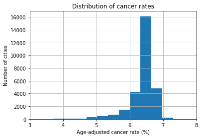

```python
combined_cancer_loc.hist(column = 'Age-adjusted cancer rate (%)',bins=20) # Similar in most places...
plt.xlabel("Age-adjusted cancer rate (%)")
plt.ylabel("Number of cities")
plt.title("Distribution of cancer rates")
plt.xlim(3,8)
plt.show()
```

From this histogram, we can see that the vast majority of cities have cancer rates between 6-7%.

Whereas for the rate of carcinogen emissions:

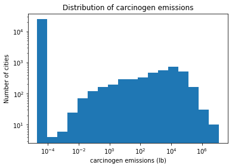

```python
x = combined_cancer_loc['Total carcinogen release (lb)'] + 0.00002 # add same offset to make up for 0s not appearing
hist, bins = np.histogram(x, bins=18)
logbins = np.logspace(np.log10(bins[0]),np.log10(bins[-1]),len(bins))
plt.hist(x, bins=logbins)
plt.xscale('log')
plt.yscale('log')
plt.title("Distribution of carcinogen emissions")
plt.xlabel("carcinogen emissions (lb)")
plt.ylabel("Number of cities")
plt.show()
```

This indicates that we have a large control group of cities without industrial activity in our dataset, to compare to the cities that do.

### Investigating the Cancer Data - All Emissions

Now that we understand the dataset, we can look at the dependence of the cancer rate on carcinogen emissions via all routes (air, water, land)

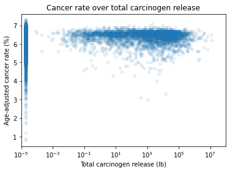

```python
combined_cancer_loc.plot.scatter(y='Age-adjusted cancer rate (%)',x='Total carcinogen release (lb)',alpha=.1)
plt.title("Cancer rate over total carcinogen release")
plt.xscale('log')
plt.xlim(0.00001,100000000)
plt.show()
```

Note that the points on the very left side represent cities where no emission data occurs, which as stated before comprises the majority of the dataset.

This plot shows that there does not appear to be a strong correlation between increased carcinogen emission and the cancer rate, in fact the pearson correlation shows:

```python
[r, p] = stats.pearsonr(combined_cancer_loc['Total carcinogen release (lb)'],combined_cancer_loc['Age-adjusted cancer rate (%)'])
print("The Pearson correlation coefficient is: ", r, "and is statistically significant with a p of ", p)
```

```
The Pearson correlation coefficient is:  -0.012171734143472304 and is statistically significant with a p of  0.0399565104363741
```

That the cancer rate actually decreases with increased emissions, at a 95% confidence level. Of course, this effect size is extremely small, and the fact that it is statistically significant most likely is only the case due to the large amount of data used. However, this does show that there is no clear correlation between emissions and cancer rate.

Another thing that may be interesting, is whether the means of cities with emissions are different than those without. As the age-adjusted cancer rate appears to be more or less normally distributed, we can use an ANOVA:

```python
no_emissions = combined_cancer_loc[combined_cancer_loc['Total carcinogen release (lb)']==0.00002]['Age-adjusted cancer rate (%)']
emissions = combined_cancer_loc[combined_cancer_loc['Total carcinogen release (lb)']!=0.00002]['Age-adjusted cancer rate (%)']
f, p = f_oneway(no_emissions,emissions)
print("The p value is",p,"therefore the two population means are not statistically different")
```

```
The p value is 0.5419706121413186 therefore the two population means are not statistically different
```

This indicates that there is no statistically significant difference between cities that have carcinogen emissions and those that do not, which follows from the trends above.

Note that this is for all carcinogen emissions, grouping together all carcinogens, as well as routes of emissions. It is likely that some carcinogens are more potent than others, while some routes cause more exposure to people. My previous analysis showed that the majority of emissions go to the air. Thinking about how the concentration of a pollutant changes as one moves away from a facility, we know see that the concentration in the air would have a cubed dependence on distance, as the emissions should move in all directions forming a semi-sphere. As such, moving away from the plant quickly dilutes the concentration of any emitted chemical - making them less harmful. Therefore, air emissions most likely only impact people surrounding the facilities and not people on the other side of a town/city. This makes the previous results even less surprising.

Yet this opens a question for other forms of emission, mainly water emissions, where the main dilution that occurs immediately is as the chemical it enters the body of water, and therefore is not as dependent on how close a person lives to the facility, but the proximity to the body of water

### Investigating the Cancer Data - Emissions to Water

We can then recreate a similar analysis with just the subset of carcinogens emitted to water:

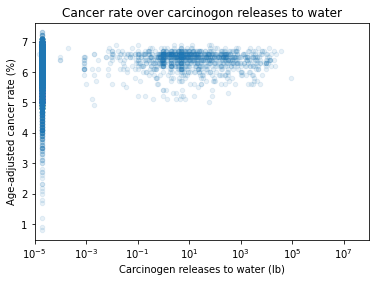

```python
gb_carcinogen_by_loc_water = df_carcinogen.groupby(['8. ST','6. CITY'])['47. 5.3 - WATER'].sum()
df_carcinogen_by_loc_water = gb_carcinogen_by_loc_water.reset_index()
combined_cancer_water = pd.merge(df_cancerData_important, df_carcinogen_by_loc_water, left_on=['StateAbbr','LocationName'],right_on=['8. ST','6. CITY'], how='left')
combined_cancer_water = combined_cancer_water.drop(columns=['8. ST','6. CITY'],index=1)
newLabels = ["State","City","Age-adjusted cancer rate (%)", "Lower CI for cancer rate","Upper CI for cancer rate","Carcinogen releases to water (lb)"]
combined_cancer_water.columns = newLabels

combined_cancer_water["Carcinogen releases to water (lb)"] = combined_cancer_water["Carcinogen releases to water (lb)"].fillna(0.00002)
combined_cancer_water.plot.scatter(y='Age-adjusted cancer rate (%)',x="Carcinogen releases to water (lb)", alpha=.1)
plt.title("Cancer rate over carcinogon releases to water")
plt.xscale('log')
plt.xlim(0.00001,100000000)
plt.show()
```

```python
[r, p] = stats.pearsonr(combined_cancer_water["Carcinogen releases to water (lb)"],combined_cancer_loc['Age-adjusted cancer rate (%)'])
print("The Pearson correlation coefficient is: ", r, "which is not statistically significant with a p combined_cancer_water ", p)
```

```
The Pearson correlation coefficient is:  -0.0060209405970291655 which is not statistically significant with a p combined_cancer_water  0.30957549497890846
```

This time the correlation is not significant, and visually we can see no clear trend. This seems to indicate that water exposure is not significantly different than air. We can also check to see if the means are the same, assuming a normal distribution again with an ANOVA

```python
no_emissions = combined_cancer_water[combined_cancer_water["Carcinogen releases to water (lb)"]==0.00002]['Age-adjusted cancer rate (%)']
emissions = combined_cancer_water[combined_cancer_water["Carcinogen releases to water (lb)"]!=0.00002]['Age-adjusted cancer rate (%)']
f, p = f_oneway(no_emissions,emissions)
print("The p value is",p,"therefore the two population means are not statistically different")
```

[output not shown]

Again, the two groups are not different, indicating that reported water emissions are not correlated to cancer rates. This is not super surprising, due to the relatively small magnitude of chemicals emitted this way, and the fact that dilution still occurs via this route.

To see if this is the case for all emissions routes, we can also check land emissions. One would think that these would affect operators/plant workers disproportionately, but not community residents as they would be less likely to be exposed.

### Investigating the Cancer Data - Emissions to Land

Recreating our analysis with emissions to land treatment:

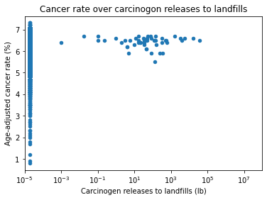

```python
gb_carcinogen_by_loc_land = df_carcinogen.groupby(['8. ST','6. CITY'])['54. 5.5.2 - LAND TREATMENT'].sum()
df_carcinogen_by_loc_land = gb_carcinogen_by_loc_land.reset_index()
df_carcinogen_by_loc_land['6. CITY'] = df_carcinogen_by_loc_land['6. CITY'].str.lower()
combined_cancer_land = pd.merge(df_cancerData_important, df_carcinogen_by_loc_land, left_on=['StateAbbr','LocationName'],right_on=['8. ST','6. CITY'], how='left')
combined_cancer_land = combined_cancer_land.drop(columns=['8. ST','6. CITY'],index=1)
newLabels = ["State","City","Age-adjusted cancer rate (%)", "Lower CI for cancer rate","Upper CI for cancer rate","Carcinogen releases to landfills (lb)"]
combined_cancer_land.columns = newLabels

combined_cancer_land["Carcinogen releases to landfills (lb)"] = combined_cancer_land["Carcinogen releases to landfills (lb)"].fillna(0.00002)
combined_cancer_land.plot.scatter(y='Age-adjusted cancer rate (%)',x="Carcinogen releases to landfills (lb)")
plt.title("Cancer rate over carcinogon releases to landfills")
plt.xscale('log')
plt.xlim(0.00001,100000000)
plt.show()
```

```python
[r, p] = stats.pearsonr(combined_cancer_land["Carcinogen releases to landfills (lb)"],combined_cancer_land['Age-adjusted cancer rate (%)'])
print("The Pearson correlation coefficient is: ", r, "and is not statistically significant with a p combined_cancer_water ", p)
```

```
The Pearson correlation coefficient is:  0.0034349917042235233 and is not statistically significant with a p combined_cancer_water  0.5621192139169562
```

Here the correlation coefficient was positive for the first time; however, said correlation was not significantly significant. Notably, there were significantly less cities with plants who reported carcinogen releases to landfills.

Checking the means again:

```python
no_emissions = combined_cancer_land[combined_cancer_land["Carcinogen releases to landfills (lb)"]==0.00002]['Age-adjusted cancer rate (%)']
emissions = combined_cancer_land[combined_cancer_land["Carcinogen releases to landfills (lb)"]!=0.00002]['Age-adjusted cancer rate (%)']
f, p = f_oneway(no_emissions,emissions)
print("The p value is",p,"therefore the two population means are not statistically different")
```

[output not shown]

So it does not appear that there is any statistically significant correlation between carcinogen release and cancer rates with this city level data. Again, this is likely because cities are large, so the majority of people are far away from any single point source, such that people who live by plants who are exposed at higher concentrations are diluted in these samples. While emissions control systems do seem to work to protect the majority of the people in the city.

## Investigating the Asthma Data

Again we can start by characterizing the distribution, this time of the rate of asthma across the country:

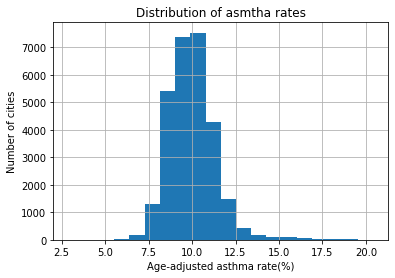

```python
df_asthmaData_important.hist(column = 'Data_Value',bins=20)
plt.xlabel('Age-adjusted asthma rate(%)')
plt.ylabel('Number of cities')
plt.title("Distribution of asmtha rates")
plt.show()
```

In this case, the asthma rate seems to vary significantly more than the cancer rate, from 7.5 - 12.5 %, which indicates that it could have stronger correlations associated with it.

### Comparing to Emissions Data

Unfortunately, the TRI does not contain emissions data for major contributors to asthma, namely NOx and particulate matter (PM). Other government programs do monitor these pollutants, which typically result from combustion. As these irritants result from combustion, it is likely that people are more commonly exposed to them by vehicle and building exhaust than point sources like plants.

Regardless, it would still be interesting to know whether or not there is any correlation between point sources and asthma rates. Although the TRI does not record some of the most prevalent asthma inducing compounds, it is likely that total chemical emissions would scale with NOx and PM emissions for point sources. As NOx and most likely come from combustion - which likely scales with other emissions as more combustion (used to provide heat to a plant) likely indicates higher production rates and therefore higher levels of emissions. Appendix A gives a validation of this correlation, by using a different government dataset - which includes county data but not city data such that it could not be compared to the PLACEs dataset. This found a significant correlation between TRI total emissions for a county and NOx/PM emissions, with a pearson's correlation coefficient of ~0.35 for both.

With this, we can compare total TRI emissions to the rate of asthma:

```python
gb_all_loc = df_TRI.groupby(['8. ST','6. CITY'])['101. TOTAL RELEASES'].sum()
df_all_loc = gb_all_loc.reset_index()
df_asthmaData_important['LocationName'] = df_asthmaData_important['LocationName'].str.lower()
combined_asthma_all = pd.merge(df_asthmaData_important, df_all_loc, left_on=['StateAbbr','LocationName'],right_on=['8. ST','6. CITY'], how='left')
combined_asthma_all = combined_asthma_all.drop(columns=['8. ST','6. CITY'],index=1)
newLabels = ["State","City","Age-adjusted asthma rate (%)", "Lower CI for asthma rate","Upper CI for asthma rate","Total chemical releases (lb)"]
combined_asthma_all.columns = newLabels
```

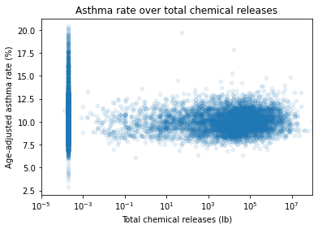

```python
combined_asthma_all["Total chemical releases (lb)"] = combined_asthma_all["Total chemical releases (lb)"].fillna(0.0002)
combined_asthma_all.plot.scatter(y='Age-adjusted asthma rate (%)',x="Total chemical releases (lb)",alpha=0.1)
plt.xlim(0.00001,100000000)
plt.xscale('log')
plt.title("Asthma rate over total chemical releases")
plt.show()
```

```python
[r, p] = stats.pearsonr(combined_asthma_all["Total chemical releases (lb)"],combined_asthma_all["Age-adjusted asthma rate (%)"])
print("The Pearson correlation coefficient is: ", r, "and is statistically significant with a p of ", p)
```

```
The Pearson correlation coefficient is:  0.012689632243090953 and is statistically significant with a p of  0.032224902510230496
```

Like the main cancer correlation, this one is also extremely weak yet statistically significant. Indicating that this total point source data is not a good predictor of asthma rates, although unlike the cancer predictor this one does find higher rates of asthma for cities with more chemical emissions. Regardless, the same conclusions about using city wide data for a more local phenomenon apply in this case. Similarly, several covariates like exposure to car exhaust could be more significant in contribution to asthma in these cities.

## Looking into the Impact of Mining

```python
df_coal = df_TRI[df_TRI["20. INDUSTRY SECTOR"] == "Coal Mining"]
df_coal = df_TRI[df_TRI["20. INDUSTRY SECTOR"] == "Coal Mining"]
df_coal = df_TRI[df_TRI["20. INDUSTRY SECTOR"] == "Coal Mining"]
gb_coal = df_coal.groupby(['8. ST','6. CITY'])['101. TOTAL RELEASES'].sum()
df_coal = gb_coal.reset_index()
df_coal['6. CITY'] = df_coal['6. CITY'].str.lower()
asthma_coal = pd.merge(df_asthmaData_important, df_coal, left_on=['StateAbbr','LocationName'],right_on=['8. ST','6. CITY'], how='left')
asthma_coal = asthma_coal.drop(columns=['8. ST','6. CITY'],index=1)
newLabels = ["State","City","Age-adjusted asthma rate (%)", "Lower CI for asthma rate","Upper CI for asthma rate","Total coal mining related releases (lb)"]
asthma_coal.columns = newLabels
asthma_coal = asthma_coal.dropna()
```

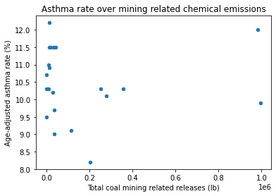

```
The Pearson correlation coefficient is:  0.03230117147036468 and is not statistically significant with a p of  0.8894546147147511
```

```python
asthma_coal.plot.scatter(y='Age-adjusted asthma rate (%)',x="Total coal mining related releases (lb)")
plt.title("Asthma rate over mining related chemical emissions")
plt.show()
[r, p] = stats.pearsonr(asthma_coal["Total coal mining related releases (lb)"],asthma_coal['Age-adjusted asthma rate (%)'])
print("The Pearson correlation coefficient is: ", r, "and is not statistically significant with a p of ", p)
```

With this small dataset, there is no correlation between the extent of mining (as measured indirectly via mining related pollution) and asthma rates. Again, likely due to the reasons listed above for the cancer dataset.

## Conclusion

This analysis failed to find strong correlations between the release of carcinogens and cancer rates or the release of chemical emissions both from all industries and specifically from coal mining and asthma rates when looking at city level data. The lack of strong correlations most likely indicates that city level data is not granular enough to see health outcomes associated with point source emissions. This is likely as all emissions are rapidly diluted as one moves away from said point source. Indicating that people close to the facility are subjected to significantly higher concentrations compared to those on the other side of the city. As such, the impact of elevated cancer or asthma rates for those close to the point source appears to be diluted by those who are not impacted. This could lead to the most likely incorrect conclusion that residents are not impacted by toxic chemical emissions at all. Likely instead, those who live closest to these facilities, who are also likely make up less privileged groups, are still impacted by emissions; however, moving away from the facility people are not impacted. Similarly, this work took all carcinogens to be the same in case of comparing to cancer rates, this is most likely not the case as some are more potent than others and could then have more negative impacts on release. While the data on coal mining was quite small and did not measure the correct indicators (like particulate matter) in order to truly represent the impact of activities like strip top mountain mining.

Regardless, this analysis could provide comfort to people who live in cities with a large amount of industrial activity - although not necessarily close to that activity - that it most likely does not impact their health.

### Future Work

It would be interesting to compare these results to health outcomes for people who live or work certain distances away from a point source, to see if elevated exposure to pollutants impacts their health outcomes and if so at what distance does this effect disappear. I would also like to look into the impact of specific higher risk carcinogens say PFOA to see if community health outcomes are different in cities which emit these in high quantities.

## Appendix A: Validating the Total TRI Emission to NOx and PM Emission Correlation

To check if assuming that the total TRI emissions is a good surrogate for NOx and PM emissions, comparison of the TRI to another dataset was completed.

The [2014 National Emissions Inventory Data](https://edap.epa.gov/public/extensions/nei_report_2014/dashboard.html#point-db) includes this. Note that the version I am using is in the data folder.

Specifically, taking the point summary file and comparing it to the 2014 TRI, we can determine if NOx and PM emissions are correlated with total TRI emissions:

```python
# Reading data from the file
df_NEI_PS = pd.read_csv('Data/NEI_Report_PointSource_Data_2014v2.txt',sep='|')
df_NEI_PS = df_NEI_PS[['STATE','STATE_COUNTY','POLLUTANT','EMISSION_TONS']]
df_NEI_PS['County'] = df_NEI_PS['STATE_COUNTY'].str.extract(r'(\w+$)')
df_NEI_PS['State'] = df_NEI_PS['STATE_COUNTY'].str.extract(r'(^\w+)')
df_NEI_PS['County'] = df_NEI_PS['County'].str.lower()
```

```python
# Want to compare to the 2014 TRI
df_TRI_2014 = pd.read_csv('https://enviro.epa.gov/enviro/efservice/MV_TRI_BASIC_DOWNLOAD/year/=/2014/fname/TRI_2014_US.csv/CSV',low_memory=False)
df_TRI_2014 = df_TRI_2014[['8. ST','7. COUNTY','34. CHEMICAL','101. TOTAL RELEASES']]
df_TRI_2014['7. COUNTY'] = df_TRI_2014['7. COUNTY'].str.lower()
df_2014_all = df_TRI_2014.groupby(['8. ST','7. COUNTY'])['101. TOTAL RELEASES'].sum().reset_index()
```

```python
df_NOx = df_NEI_PS[df_NEI_PS['POLLUTANT']=='Nitrogen Oxides']
df_PM = df_NEI_PS[df_NEI_PS['POLLUTANT']=='PM10']
df_NOx = df_NOx.groupby(['State','County'])['EMISSION_TONS'].sum().reset_index()
df_PM = df_PM.groupby(['State','County'])['EMISSION_TONS'].sum().reset_index()
```

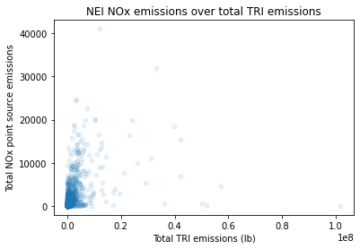

```
The Pearson correlation coefficient is:  0.3768009840208473 and is statistically significant with a p of  1.1064697360661805e-62
```

```python
combined_NOx = pd.merge(df_NOx, df_2014_all, left_on=['State','County'],right_on=['8. ST','7. COUNTY'], how='left')
combined_NOx = combined_NOx.dropna() # drops AK due to name conventions
combined_NOx.plot.scatter(x='101. TOTAL RELEASES',y='EMISSION_TONS',alpha=0.1)
plt.xlabel("Total TRI emissions (lb)")
plt.ylabel("Total NOx point source emissions")
plt.title("NEI NOx emissions over total TRI emissions")
plt.show()
[r, p] = stats.pearsonr(combined_NOx["101. TOTAL RELEASES"],combined_NOx['EMISSION_TONS'])
print("The Pearson correlation coefficient is: ", r, "and is statistically significant with a p of ", p)
```

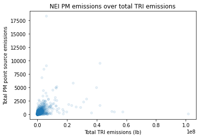

```
The Pearson correlation coefficient is:  0.3559515525784859 and is statistically significant with a p of  1.1922644287517598e-51
```

```python
combined_PM = pd.merge(df_PM, df_2014_all, left_on=['State','County'],right_on=['8. ST','7. COUNTY'], how='left')
combined_PM = combined_PM.dropna()
combined_PM.plot.scatter(x='101. TOTAL RELEASES',y='EMISSION_TONS',alpha=0.1)
plt.xlabel("Total TRI emissions (lb)")
plt.ylabel("Total PM point source emissions")
plt.title("NEI PM emissions over total TRI emissions")
plt.show()
[r, p] = stats.pearsonr(combined_PM["101. TOTAL RELEASES"],combined_PM['EMISSION_TONS'])
print("The Pearson correlation coefficient is: ", r, "and is statistically significant with a p of ", p)
```

The Pearson correlation coefficient of ~0.35 for both of these pollutants shows that there is a positive correlation between these two values, indicating that using the TRI as a surrogate for these two chemicals is not exact, but at least follows the same general trend.